# Serum ferritin and delirium risk: Integrative genomic analysis identifies locus-specific signals at 19q13

Ferritin and Delirium: A genetic dissection

2026-01-02

## 1 Title Page

Authors list:

1. Amirhossein Saed
2. Mahdi Akbarzadeh
3. Fatemeh Gohari
4. Nafiseh Asadrouh
5. Amir Mohammad Jahromizadeh
6. Hani Sabaie
7. Maryam Zarkesh
8. Mehdi Hedayati
9. Fereidoun Azizi
10. Maryam Sadat Daneshpour

## 2 Data and preprocessing

### 2.1 Introduction

Exposure: Ferritin | GWAS summary statistics: [GWAS catalogue](https://www.ebi.ac.uk/gwas/studies/GCST90270865) | Reference paper: [Butler-Laporte G et al.2023](https://pubmed.ncbi.nlm.nih.gov/36773317/)

- Sample size: 270,794
- Ancestry: European

Outcome: Delirium | GWAS summary statistics: [GWAS catalogue](https://www.ebi.ac.uk/gwas/studies/GCST90473243) | Reference paper: [UK Biobank Whole-Genome Sequencing Consortium](https://www.ebi.ac.uk/gwas/studies/GCST90473243)

- Sample size: 458,440
- Ancestry: European

### 2.2 Data Prepration

**Ferritin GWAS:**

- Number of total SNPs in the raw exposure file: 10,251,641
- Number of total SNPs in the harmonized exposure file: 10,218,238
- Number of total SNPs with invalid rsID: 0
- Number of total SNPs with invalid alleles: 0
- Number of total SNPs with 0.42 < MAF < 0.58: 0
- Number of total SNPs with non-numeric se/b/p: 0

**Delirium GWAS:**

## 3 Integrated results across MR, SMR/HEIDI, coloc and SuSiE

### 3.1 **Two-sample MR**

**Integrated MR interpretation.** The primary IVW (random-effects) estimate is **non-significant** (OR = 1.086, 95% CI 0.935–1.261; p = 0.282). There is evidence of heterogeneity (IVW Cochran’s Q p = 0.015), but no evidence of *directional* pleiotropy (MR-Egger intercept p = 0.506). Steiger filtering supports the direction Ferritin → Delirium (R²<sub>x</sub> > R²<sub>y</sub>; p = 0e+00). MR-PRESSO detects outliers (global p = 0.017), but the distortion test is non-significant (p = 0.705), so the outlier-corrected nominal association should be treated as **exploratory**.

Instruments

70 SNPs

Ferritin → Delirium

Instrument strength ?F-statistic gauges instrument strength; a common rule-of-thumb is F ≥ 10. Mean F = 78.76 indicates strong instruments and low risk of weak-IV bias.

78.76

Mean F-statistic

Heterogeneity ?Cochran’s Q tests whether per-SNP ratio estimates vary more than expected by chance; significant Q suggests heterogeneity (often pleiotropy or multiple mechanisms).

Q p = 0.015

Cochran’s Q (IVW)

Directional pleiotropy ?MR-Egger intercept tests unbalanced (directional) horizontal pleiotropy; non-significant intercept suggests no consistent directional bias.

p = 0.506

MR-Egger intercept

Directionality ?Steiger compares variance explained in exposure vs outcome; if R²_exposure > R²_outcome, Ferritin → Delirium is supported over reverse.

Supported

Steiger p = 0e+00

Outliers ?MR-PRESSO tests for outlier instruments (global test) and whether removing them significantly changes the estimate (distortion test).

1

Global p = 0.017; Distortion p = 0.705

Download: MR main table

Table S1. Two-sample MR estimates for ferritin → delirium across estimators.

| Method | N SNPs | β (log OR) | SE | OR (95% CI) | p |
| --- | --- | --- | --- | --- | --- |
| IVW (multiplicative random effects) | 70 | 0.0822 | 0.0765 | 1.086 (0.935–1.261) | 0.282 |
| MR-Egger | 70 | 0.1617 | 0.1415 | 1.176 (0.891–1.551) | 0.257 |
| Weighted median | 70 | 0.0899 | 0.0974 | 1.094 (0.904–1.324) | 0.356 |

**Table S1.** Two-sample MR causal estimates for ferritin → delirium across IVW, MR-Egger, and weighted median (OR per SD higher ferritin).

Table S2. Diagnostic summary for strength, heterogeneity, pleiotropy, directionality, and outliers.

| Test | Result |
| --- | --- |
| Instrument strength ?Mean F-statistic summarises strength; a common heuristic is F ≥ 10. | Mean F = 78.76 |
| Heterogeneity (IVW) ?Cochran’s Q p-value tests whether ratio estimates are heterogeneous. | Q = 97.00 (df=69), p = 0.015 |
| Directional pleiotropy ?MR-Egger intercept p-value tests directional pleiotropy. | Intercept = -0.0035 (SE=0.0052), p = 0.506 |
| Directionality (Steiger) ?Steiger supports Ferritin → Delirium if R²_exposure > R²_outcome. | R²x = 0.020643; R²y = 0.000218; direction = Ferritin → Delirium; p = 0e+00 |
| Outliers (MR-PRESSO) ?Global test detects outliers; distortion test asks if estimate changes materially after removal. | Global p = 0.017; Distortion p = 0.705; outliers = 1 |
| MR-PRESSO outlier-corrected estimate | β = 0.1198 (SE=0.0585), OR = 1.127 (1.005–1.264), p = 0.045 |

**Table S2.** Instrument diagnostics for ferritin → delirium, including strength (F), heterogeneity (Cochran’s Q), directional pleiotropy (Egger intercept), directionality (Steiger), and MR-PRESSO outlier assessment.

Download: Table S3. MR heterogeneity

**Table S3.** Cochran’s Q heterogeneity statistics for IVW and MR-Egger models (Q, df, p).

Download: Table S4. MR pleiotropy

**Table S4.** MR-Egger intercept test for directional pleiotropy (intercept, SE, p).

Download: Table S5. MR Steiger

**Table S5.** Steiger filtering results comparing variance explained in exposure vs outcome (R²x, R²y) and inferred causal direction.

Download: Table S6. MR-PRESSO

**Table S6.** MR-PRESSO raw and outlier-corrected causal estimates for ferritin → delirium, including OR.

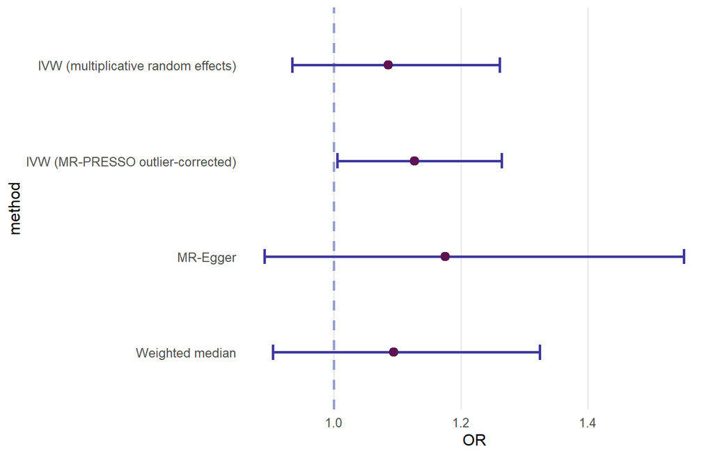

**Figure S1. Causal estimates across MR estimators.** OR= Odds Ratio.Estimates are directionally consistent; primary IVW (randomeffects) interval includes the null.

**Diagnostics (MR)**

#### Figure S2. MR scatter plot

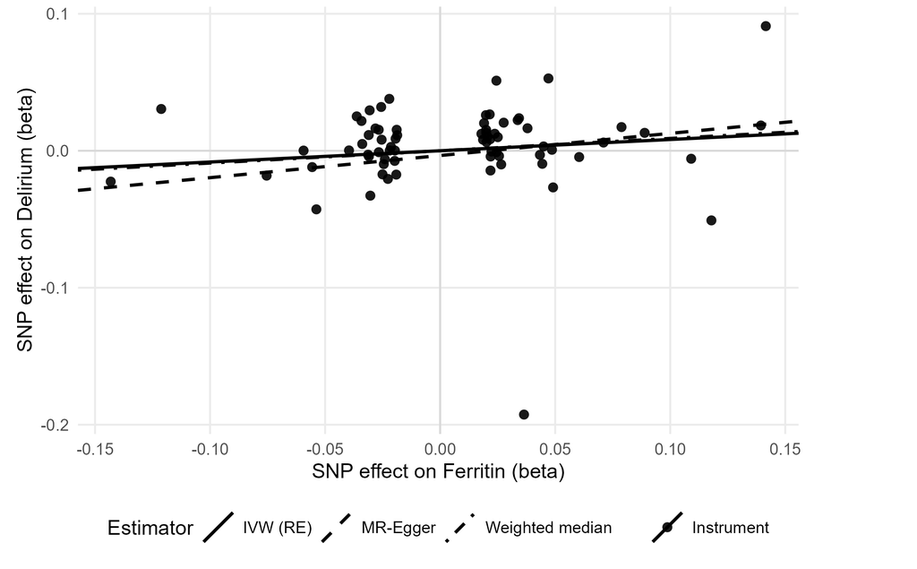

Scatter of per-SNP effects (ferritin vs delirium) with estimator lines; approximate alignment of slopes supports method-level consistency in direction.

#### Figure S3. Funnel plot

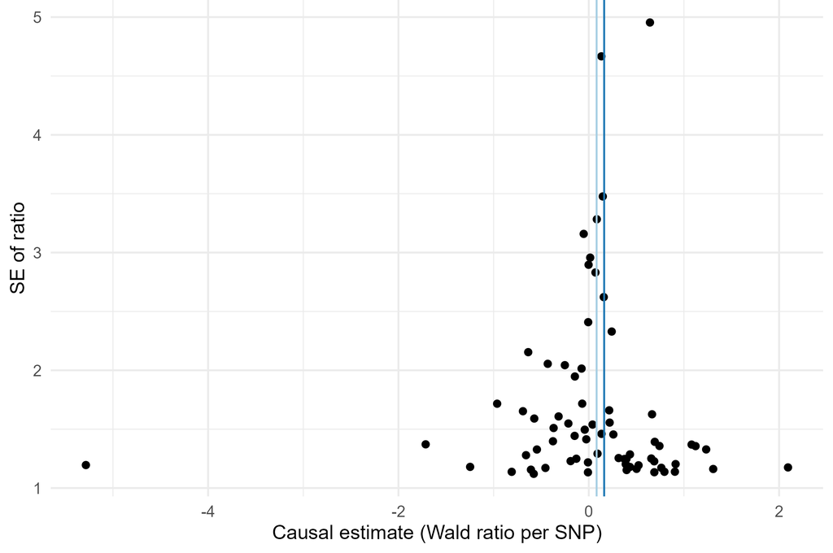

Funnel plot of per-SNP Wald ratio estimates versus their standard errors to screen for outliers.

#### Figure S4. Leave-one-out influence plot

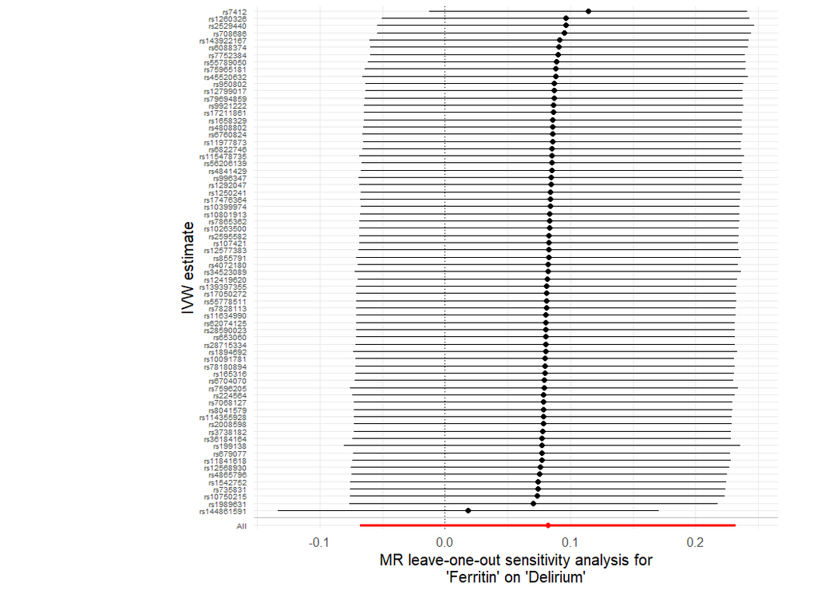

Stability of the IVW estimate under leave-one-out suggests the inference is not driven by a single SNP.

#### Figure S5. MR-PRESSO outlier plot

[figure not shown]

MR-PRESSO outlier map showing studentized residuals versus leverage (hat values) for instruments, with global and distortion test p-values and identified outliers.

### 3.2 **SMR/HEIDI**

**SMR/HEIDI highlights.** Across 43 cis-QTL panels per trait (tissues: Blood, Brain, Pituitary, Liver, Spleen, KidneyCortex; omics: eQTL/mQTL/sQTL/pQTL), Ferritin shows a broad cis-mediated architecture, whereas Delirium retains sparse signals concentrated in a few panels. Under strict Bonferroni+HEIDI (panel-wise Bonferroni + p<sub>HEIDI</sub> ≥ 0.01 + n<sub>SNP,HEIDI</sub> ≥ 3), Ferritin retains **344** probe–panel records (**255** unique probes; **126** genes), Delirium retains **4** probe–panel records (**4** unique probes; **3** genes), and the strict cross-trait intersection is **APOE**.

Ferritin retained

344 records

255 probes • 126 genes

Delirium retained

4 records

4 probes • 3 genes

Strict overlap

APOE

Shared genes (BF+HEIDI)

Ferritin panels w/ hits

43 / 43

Any BF+HEIDI pass

Delirium panels w/ hits

4 / 43

Any BF+HEIDI pass

Download: Table S7 (panel summary)

**Table S7.** SMR/HEIDI panel-level summary by trait, tissue, omics layer, and QTL panel, reporting probes/genes passing Bonferroni+HEIDI and the most significant retained signal per panel.

Download: Table S8 (BF+HEIDI probe-level hits)

**Table S8.** Probe-level SMR hits retained after panel-wise Bonferroni and HEIDI filtering, with lead SNP, effect estimates, and HEIDI diagnostics across traits and panels.

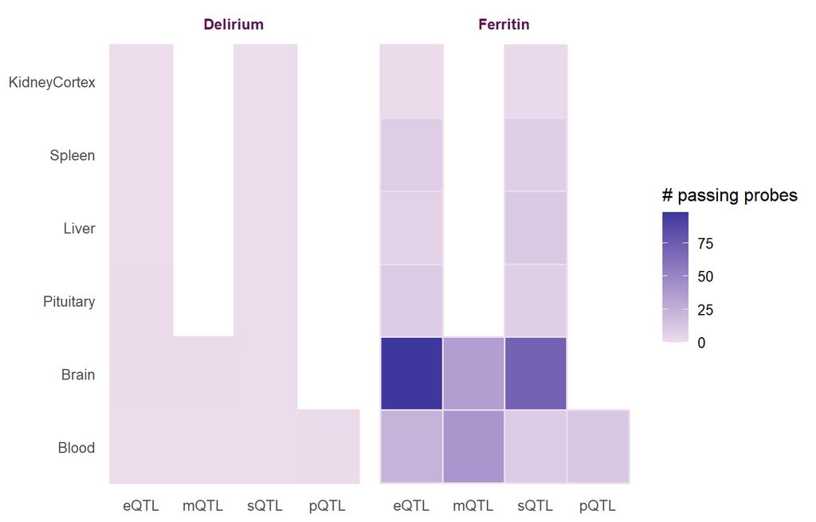

**Figure S6.** Tissue × omics yield heatmap (sum of BF+HEIDI passing probes across panels). Heatmap of aggregated BF+HEIDI passing probe counts across panels by tissue and omics layer, shown separately for Delirium, on the left, and Ferritin, on the right.

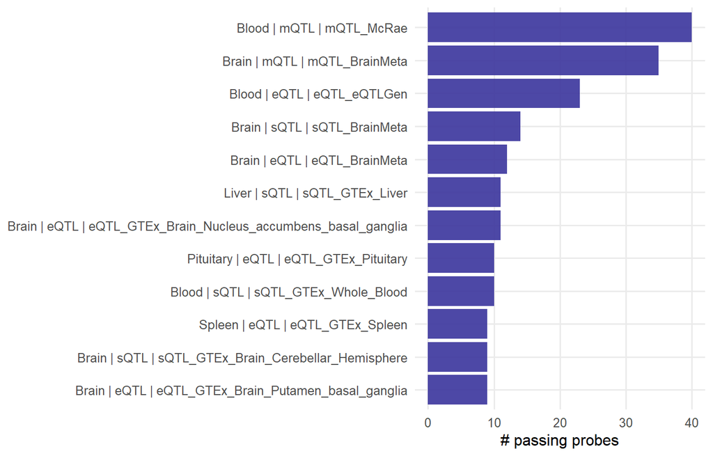

**Figure S7.** Highest-yield Ferritin panels by number of BF+HEIDI passing probes. Ferritin cis-QTL panels ranked by the number of BF+HEIDI passing probes. Horizontal bars represent passing probe counts per xQTL panel.

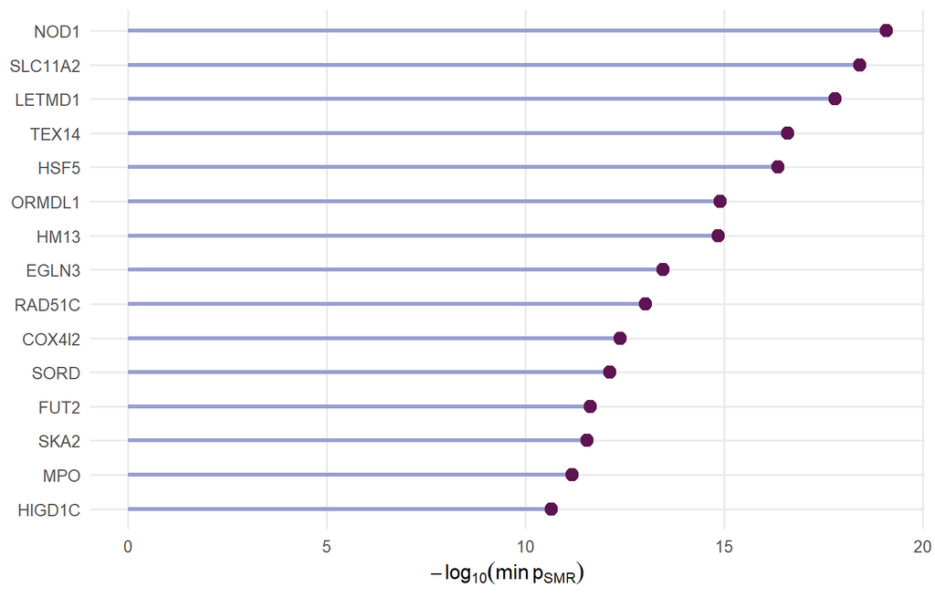

**Figure S8.** Top Ferritin genes based on SMR significance. Top Ferritin genes ranked by the most significant SMR association per gene (minimum p<sub>SMR</sub> across BF+HEIDI passing records).

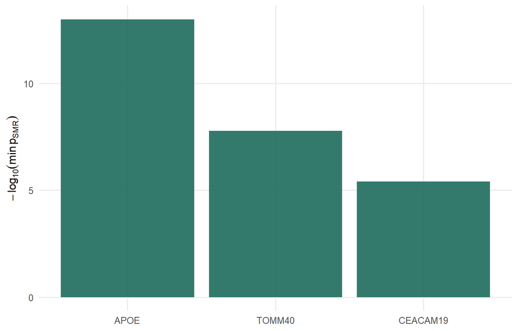

**Figure S9.** Delirium retained genes (best pSMR per gene). All three signals are located at the 19q13 locus.

| gene | tissue | omics | qtl_name | probe_id | chr | pos | top_snp | b_smr | se_smr | p_smr | p_heidi | nsnp_heidi | p_bonf_panel | M_panel |
| --- | --- | --- | --- | --- | --- | --- | --- | --- | --- | --- | --- | --- | --- | --- |
| APOE | Blood | pQTL | pQTL_INTERVAL | APOE.5312.49.3 | 19 | 45410828 | rs814573 | 1.783890 | 0.239779 | 1.0e-13 | 0.055 | 17 | 8.1e-05 | 616 |
| TOMM40 | Brain | mQTL | mQTL_BrainMeta | cg02613937 | 19 | 44892040 | rs59007384 | -1.117160 | 0.197970 | 1.7e-08 | 0.310 | 10 | 3.4e-06 | 14588 |
| CEACAM19 | Brain | eQTL | eQTL_BrainMeta | ENSG00000186567.13 | 19 | 44673316 | rs714948 | 0.107122 | 0.023200 | 3.9e-06 | 0.044 | 20 | 4.8e-06 | 10514 |
| CEACAM19 | Pituitary | eQTL | eQTL_GTEx_Pituitary | ENSG00000186567.12 | 19 | 44666958 | rs714948 | 0.142554 | 0.033446 | 2.0e-05 | 0.621 | 14 | 2.1e-05 | 2402 |

**Table S9.** All Delirium SMR associations retained under Bonferroni+HEIDI, listing locus details, lead SNP, SMR effect, and HEIDI statistics.

| trait | gene | tissue | omics | qtl_name | probe_id | chr | pos | top_snp | b_smr | se_smr | p_smr | p_heidi | nsnp_heidi | p_bonf_panel | M_panel |
| --- | --- | --- | --- | --- | --- | --- | --- | --- | --- | --- | --- | --- | --- | --- | --- |
| Delirium | APOE | Blood | pQTL | pQTL_INTERVAL | APOE.5312.49.3 | 19 | 45410828 | rs814573 | 1.783890 | 0.239779 | 1.0e-13 | 0.055 | 17 | 8.1e-05 | 616 |
| Ferritin | APOE | Blood | pQTL | pQTL_INTERVAL | APOE.2937.10.2 | 19 | 45410828 | rs1065853 | -0.050535 | 0.009283 | 5.2e-08 | 0.589 | 20 | 8.1e-05 | 616 |

**Table S10.** Strict cross-trait overlap of BF+HEIDI-retained genes, showing matching retained records for the shared gene(s) across Ferritin and Delirium.

| tissue | omics | Delirium | Ferritin |
| --- | --- | --- | --- |
| Blood | eQTL | 0 | 23 |
| Blood | mQTL | 0 | 40 |
| Blood | sQTL | 0 | 10 |
| Blood | pQTL | 1 | 12 |
| Brain | eQTL | 1 | 98 |
| Brain | mQTL | 1 | 35 |
| Brain | sQTL | 0 | 71 |
| Pituitary | eQTL | 1 | 10 |
| Pituitary | sQTL | 0 | 8 |
| Liver | eQTL | 0 | 6 |
| Liver | sQTL | 0 | 11 |
| Spleen | eQTL | 0 | 9 |
| Spleen | sQTL | 0 | 8 |
| KidneyCortex | eQTL | 0 | 1 |
| KidneyCortex | sQTL | 0 | 2 |

**Table S11.** Aggregated counts of Bonferroni+HEIDI passing probes by tissue and omics layer, shown separately for Ferritin and Delirium.

| trait | tissue | omics | qtl_name | M_tested_unique_probes | p_bonf_panel | n_pass_probes | n_pass_unique_genes | n_pass_unique_probe_id | min_p_smr_pass | top_gene_pass | top_probe_pass | top_snp_pass |
| --- | --- | --- | --- | --- | --- | --- | --- | --- | --- | --- | --- | --- |
| Delirium | Blood | eQTL | eQTL_eQTLGen | 11106 | 4.5e-06 | 0 | 0 | 0 | NA |  |  |  |
| Delirium | Blood | mQTL | mQTL_McRae | 13139 | 3.8e-06 | 0 | 0 | 0 | NA |  |  |  |
| Delirium | Blood | pQTL | pQTL_FENLAND | 1540 | 3.2e-05 | 0 | 0 | 0 | NA |  |  |  |
| Delirium | Blood | pQTL | pQTL_INTERVAL | 616 | 8.1e-05 | 1 | 1 | 1 | 1.0e-13 | APOE | APOE.5312.49.3 | rs814573 |
| Delirium | Blood | pQTL | pQTL_SCALLOP | 71 | 7.0e-04 | 0 | 0 | 0 | NA |  |  |  |
| Delirium | Blood | sQTL | sQTL_GTEx_Whole_Blood | 1919 | 2.6e-05 | 0 | 0 | 0 | NA |  |  |  |
| Delirium | Brain | eQTL | eQTL_BrainMeta | 10514 | 4.8e-06 | 1 | 1 | 1 | 3.9e-06 | CEACAM19 | ENSG00000186567.13 | rs714948 |
| Delirium | Brain | eQTL | eQTL_GTEx_Brain_Amygdala | 767 | 6.5e-05 | 0 | 0 | 0 | NA |  |  |  |
| Delirium | Brain | eQTL | eQTL_GTEx_Brain_Anterior_cingulate_cortex_BA24 | 1151 | 4.3e-05 | 0 | 0 | 0 | NA |  |  |  |
| Delirium | Brain | eQTL | eQTL_GTEx_Brain_Caudate_basal_ganglia | 2050 | 2.4e-05 | 0 | 0 | 0 | NA |  |  |  |
| Delirium | Brain | eQTL | eQTL_GTEx_Brain_Cerebellar_Hemisphere | 2712 | 1.8e-05 | 0 | 0 | 0 | NA |  |  |  |
| Delirium | Brain | eQTL | eQTL_GTEx_Brain_Cerebellum | 3387 | 1.5e-05 | 0 | 0 | 0 | NA |  |  |  |
| Delirium | Brain | eQTL | eQTL_GTEx_Brain_Cortex | 2381 | 2.1e-05 | 0 | 0 | 0 | NA |  |  |  |
| Delirium | Brain | eQTL | eQTL_GTEx_Brain_Frontal_Cortex_BA9 | 1769 | 2.8e-05 | 0 | 0 | 0 | NA |  |  |  |
| Delirium | Brain | eQTL | eQTL_GTEx_Brain_Hippocampus | 1277 | 3.9e-05 | 0 | 0 | 0 | NA |  |  |  |
| Delirium | Brain | eQTL | eQTL_GTEx_Brain_Hypothalamus | 1244 | 4.0e-05 | 0 | 0 | 0 | NA |  |  |  |
| Delirium | Brain | eQTL | eQTL_GTEx_Brain_Nucleus_accumbens_basal_ganglia | 1949 | 2.6e-05 | 0 | 0 | 0 | NA |  |  |  |
| Delirium | Brain | eQTL | eQTL_GTEx_Brain_Putamen_basal_ganglia | 1671 | 3.0e-05 | 0 | 0 | 0 | NA |  |  |  |
| Delirium | Brain | eQTL | eQTL_GTEx_Brain_Spinal_cord_cervical_c-1 | 1065 | 4.7e-05 | 0 | 0 | 0 | NA |  |  |  |
| Delirium | Brain | eQTL | eQTL_GTEx_Brain_Substantia_nigra | 694 | 7.2e-05 | 0 | 0 | 0 | NA |  |  |  |
| Delirium | Brain | mQTL | mQTL_BrainMeta | 14588 | 3.4e-06 | 1 | 1 | 1 | 1.7e-08 | TOMM40 | cg02613937 | rs59007384 |
| Delirium | Brain | sQTL | sQTL_BrainMeta | 9457 | 5.3e-06 | 0 | 0 | 0 | NA |  |  |  |
| Delirium | Brain | sQTL | sQTL_GTEx_Brain_Amygdala | 827 | 6.0e-05 | 0 | 0 | 0 | NA |  |  |  |
| Delirium | Brain | sQTL | sQTL_GTEx_Brain_Anterior_cingulate_cortex_BA24 | 1016 | 4.9e-05 | 0 | 0 | 0 | NA |  |  |  |
| Delirium | Brain | sQTL | sQTL_GTEx_Brain_Caudate_basal_ganglia | 1313 | 3.8e-05 | 0 | 0 | 0 | NA |  |  |  |
| Delirium | Brain | sQTL | sQTL_GTEx_Brain_Cerebellar_Hemisphere | 1801 | 2.8e-05 | 0 | 0 | 0 | NA |  |  |  |
| Delirium | Brain | sQTL | sQTL_GTEx_Brain_Cerebellum | 1966 | 2.5e-05 | 0 | 0 | 0 | NA |  |  |  |
| Delirium | Brain | sQTL | sQTL_GTEx_Brain_Cortex | 1486 | 3.4e-05 | 0 | 0 | 0 | NA |  |  |  |
| Delirium | Brain | sQTL | sQTL_GTEx_Brain_Frontal_Cortex_BA9 | 1283 | 3.9e-05 | 0 | 0 | 0 | NA |  |  |  |
| Delirium | Brain | sQTL | sQTL_GTEx_Brain_Hippocampus | 980 | 5.1e-05 | 0 | 0 | 0 | NA |  |  |  |

[output cut: 56 more lines]

**Table S12.** Panel-level SMR/HEIDI results by trait, tissue, omics layer, and QTL panel, reporting the number of tested probes, panel-wise Bonferroni threshold, BF+HEIDI passing counts, and the top retained signal per panel.

| trait | tissue | omics | qtl_name | probe_id | gene | chr | pos | top_snp | b_smr | se_smr | p_smr | p_heidi | nsnp_heidi | p_bonf_panel | M_panel | source_file |
| --- | --- | --- | --- | --- | --- | --- | --- | --- | --- | --- | --- | --- | --- | --- | --- | --- |
| Delirium | Blood | pQTL | pQTL_INTERVAL | APOE.5312.49.3 | APOE | 19 | 45410828 | rs814573 | 1.783890 | 0.239779 | 1.0e-13 | 0.055 | 17 | 8.1e-05 | 616 | Delirium Blood pQTL.tsv |
| Delirium | Brain | mQTL | mQTL_BrainMeta | cg02613937 | TOMM40 | 19 | 44892040 | rs59007384 | -1.117160 | 0.197970 | 1.7e-08 | 0.310 | 10 | 3.4e-06 | 14588 | Delirium Brain Pituitary mQTL.tsv |
| Delirium | Brain | eQTL | eQTL_BrainMeta | ENSG00000186567.13 | CEACAM19 | 19 | 44673316 | rs714948 | 0.107122 | 0.023200 | 3.9e-06 | 0.044 | 20 | 4.8e-06 | 10514 | Delirium Brain Pituitary eQTL.tsv |
| Delirium | Pituitary | eQTL | eQTL_GTEx_Pituitary | ENSG00000186567.12 | CEACAM19 | 19 | 44666958 | rs714948 | 0.142554 | 0.033446 | 2.0e-05 | 0.621 | 14 | 2.1e-05 | 2402 | Delirium Brain Pituitary eQTL.tsv |
| Ferritin | Brain | sQTL | sQTL_BrainMeta | chr7:30499657:30503225:clu_265761_ | NOD1 | 7 | 30461825 | rs2190504 | 0.058387 | 0.006408 | 8.1e-20 | 0.018 | 20 | 5.3e-06 | 9471 | Ferritin Brain Pituitary sQTL.tsv |
| Ferritin | Blood | eQTL | eQTL_eQTLGen | ENSG00000110911 | SLC11A2 | 12 | 51003984 | rs1095998 | 0.204454 | 0.022858 | 3.7e-19 | 0.017 | 20 | 4.5e-06 | 11110 | Ferritin Blood Spleen eQTL.tsv |
| Ferritin | Blood | eQTL | eQTL_eQTLGen | ENSG00000050426 | LETMD1 | 12 | 51054193 | rs7972608 | -0.173048 | 0.019706 | 1.6e-18 | 0.069 | 20 | 4.5e-06 | 11110 | Ferritin Blood Spleen eQTL.tsv |
| Ferritin | Spleen | sQTL | sQTL_GTEx_Spleen | chr7:30460041:30478606:clu_28614:ENSG00000106100.10 | NOD1 | 7 | 30460041 | rs2529440 | -0.028206 | 0.003224 | 2.2e-18 | 0.017 | 20 | 2.5e-05 | 2001 | Ferritin Blood Spleen sQTL.tsv |
| Ferritin | Blood | mQTL | mQTL_McRae | cg19208681 | TEX14 | 17 | 58692267 | rs8082334 | 0.101069 | 0.011934 | 2.5e-17 | 0.019 | 20 | 3.8e-06 | 13148 | Ferritin Blood mQTL.tsv |
| Ferritin | Brain | mQTL | mQTL_BrainMeta | cg22956635 | HSF5 | 17 | 58489037 | rs2240719 | 0.058380 | 0.006946 | 4.3e-17 | 0.100 | 3 | 3.4e-06 | 14598 | Ferritin Brain Pituitary mQTL.tsv |
| Ferritin | Pituitary | eQTL | eQTL_GTEx_Pituitary | ENSG00000128699.13 | ORMDL1 | 2 | 189770323 | rs6741074 | -0.070880 | 0.008861 | 1.3e-15 | 0.019 | 20 | 2.1e-05 | 2407 | Ferritin Brain Pituitary eQTL.tsv |
| Ferritin | Blood | eQTL | eQTL_eQTLGen | ENSG00000101294 | HM13 | 20 | 31546166 | rs6119489 | -0.067206 | 0.008415 | 1.4e-15 | 0.405 | 20 | 4.5e-06 | 11110 | Ferritin Blood Spleen eQTL.tsv |
| Ferritin | Blood | mQTL | mQTL_McRae | cg19548652 | EGLN3 | 14 | 33950110 | rs1032014 | 0.159252 | 0.021009 | 3.5e-14 | 0.882 | 20 | 3.8e-06 | 13148 | Ferritin Blood mQTL.tsv |
| Ferritin | Brain | eQTL | eQTL_GTEx_Brain_Hypothalamus | ENSG00000108384.14 | RAD51C | 17 | 58692573 | rs67014405 | 0.070011 | 0.009398 | 9.4e-14 | 0.019 | 20 | 4.0e-05 | 1247 | Ferritin Brain Pituitary eQTL.tsv |
| Ferritin | Blood | mQTL | mQTL_McRae | cg18721089 | COX4I2 | 20 | 31632833 | rs6060409 | 0.049402 | 0.006811 | 4.1e-13 | 0.266 | 20 | 3.8e-06 | 13148 | Ferritin Blood mQTL.tsv |
| Ferritin | Spleen | eQTL | eQTL_GTEx_Spleen | ENSG00000140263.13 | SORD | 15 | 45023104 | rs4774514 | 0.211777 | 0.029529 | 7.4e-13 | 0.057 | 17 | 1.7e-05 | 2968 | Ferritin Blood Spleen eQTL.tsv |
| Ferritin | Blood | mQTL | mQTL_McRae | cg04660111 | FUT2 | 19 | 48695977 | rs507855 | -0.051447 | 0.007335 | 2.3e-12 | 0.126 | 20 | 3.8e-06 | 13148 | Ferritin Blood mQTL.tsv |
| Ferritin | Brain | mQTL | mQTL_BrainMeta | cg19273756 | SKA2 | 17 | 59152330 | rs7502947 | 0.067934 | 0.009721 | 2.8e-12 | 0.208 | 13 | 3.4e-06 | 14598 | Ferritin Brain Pituitary mQTL.tsv |
| Ferritin | Spleen | eQTL | eQTL_GTEx_Spleen | ENSG00000108384.14 | RAD51C | 17 | 58692573 | rs28687626 | -0.085677 | 0.012415 | 5.2e-12 | 0.018 | 20 | 1.7e-05 | 2968 | Ferritin Blood Spleen eQTL.tsv |
| Ferritin | Blood | pQTL | pQTL_INTERVAL | MPO.2580.83.2 | MPO | 17 | 56352756 | rs75394768 | -0.114869 | 0.016734 | 6.7e-12 | 0.024 | 20 | 8.1e-05 | 616 | Ferritin Blood pQTL.tsv |
| Ferritin | Pituitary | sQTL | sQTL_GTEx_Pituitary | chr7:30460041:30478606:clu_31333:ENSG00000106100.10 | NOD1 | 7 | 30460041 | rs2190504 | -0.041620 | 0.006093 | 8.5e-12 | 0.052 | 20 | 2.4e-05 | 2047 | Ferritin Brain Pituitary sQTL.tsv |
| Ferritin | Brain | mQTL | mQTL_BrainMeta | cg23436779 | RAD51C | 17 | 58692469 | rs35987270 | 0.078091 | 0.011663 | 2.1e-11 | 0.014 | 8 | 3.4e-06 | 14598 | Ferritin Brain Pituitary mQTL.tsv |
| Ferritin | Brain | mQTL | mQTL_BrainMeta | cg20872692 | HIGD1C | 12 | 50987352 | rs7138860 | 0.129066 | 0.019291 | 2.2e-11 | 0.012 | 8 | 3.4e-06 | 14598 | Ferritin Brain Pituitary mQTL.tsv |
| Ferritin | Brain | eQTL | eQTL_GTEx_Brain_Cerebellar_Hemisphere | ENSG00000128699.13 | ORMDL1 | 2 | 189770323 | rs10207346 | -0.087641 | 0.013108 | 2.3e-11 | 0.016 | 20 | 1.8e-05 | 2721 | Ferritin Brain Pituitary eQTL.tsv |
| Ferritin | Brain | sQTL | sQTL_GTEx_Brain_Cerebellar_Hemisphere | chr17:59954146:59956488:clu_12266:ENSG00000189050.15 | RNFT1 | 17 | 59954146 | rs1292046 | -0.046699 | 0.007124 | 5.6e-11 | 0.030 | 20 | 2.8e-05 | 1805 | Ferritin Brain Pituitary sQTL.tsv |
| Ferritin | Blood | mQTL | mQTL_McRae | cg07425170 | FNBP4 | 11 | 47767526 | rs12223593 | -0.055917 | 0.008572 | 6.9e-11 | 0.144 | 20 | 3.8e-06 | 13148 | Ferritin Blood mQTL.tsv |
| Ferritin | Brain | eQTL | eQTL_GTEx_Brain_Nucleus_accumbens_basal_ganglia | ENSG00000108384.14 | RAD51C | 17 | 58692573 | rs12948424 | 0.083670 | 0.012881 | 8.3e-11 | 0.025 | 20 | 2.6e-05 | 1959 | Ferritin Brain Pituitary eQTL.tsv |
| Ferritin | Brain | mQTL | mQTL_BrainMeta | cg21846177 | DEFB124 | 20 | 31485773 | rs2064818 | -0.043443 | 0.006718 | 1.0e-10 | 0.016 | 18 | 3.4e-06 | 14598 | Ferritin Brain Pituitary mQTL.tsv |
| Ferritin | Blood | mQTL | mQTL_McRae | cg01065977 | ISYNA1 | 19 | 18438879 | rs4303657 | -0.017060 | 0.002642 | 1.1e-10 | 0.023 | 20 | 3.8e-06 | 13148 | Ferritin Blood mQTL.tsv |
| Ferritin | Blood | pQTL | pQTL_FENLAND | X5223_59_GCKR | GCKR | 2 | 27496839 | rs1260326 | -0.068675 | 0.010767 | 1.8e-10 | 0.794 | 20 | 3.2e-05 | 1542 | Ferritin Blood pQTL.tsv |

[output cut: 318 more lines]

**Table S13.** Complete Bonferroni+HEIDI-retained SMR hit list across both traits, including panel metadata, lead SNP, SMR effect/SE, p-values, and HEIDI support.

| gene | tissue | omics | qtl_name | probe_id | chr | pos | top_snp | b_smr | se_smr | p_smr | p_heidi | nsnp_heidi |
| --- | --- | --- | --- | --- | --- | --- | --- | --- | --- | --- | --- | --- |
| NOD1 | Brain | sQTL | sQTL_BrainMeta | chr7:30499657:30503225:clu_265761_ | 7 | 30461825 | rs2190504 | 0.058387 | 0.006408 | 8.1e-20 | 0.018 | 20 |
| SLC11A2 | Blood | eQTL | eQTL_eQTLGen | ENSG00000110911 | 12 | 51003984 | rs1095998 | 0.204454 | 0.022858 | 3.7e-19 | 0.017 | 20 |
| LETMD1 | Blood | eQTL | eQTL_eQTLGen | ENSG00000050426 | 12 | 51054193 | rs7972608 | -0.173048 | 0.019706 | 1.6e-18 | 0.069 | 20 |
| NOD1 | Spleen | sQTL | sQTL_GTEx_Spleen | chr7:30460041:30478606:clu_28614:ENSG00000106100.10 | 7 | 30460041 | rs2529440 | -0.028206 | 0.003224 | 2.2e-18 | 0.017 | 20 |
| TEX14 | Blood | mQTL | mQTL_McRae | cg19208681 | 17 | 58692267 | rs8082334 | 0.101069 | 0.011934 | 2.5e-17 | 0.019 | 20 |
| HSF5 | Brain | mQTL | mQTL_BrainMeta | cg22956635 | 17 | 58489037 | rs2240719 | 0.058380 | 0.006946 | 4.3e-17 | 0.100 | 3 |
| ORMDL1 | Pituitary | eQTL | eQTL_GTEx_Pituitary | ENSG00000128699.13 | 2 | 189770323 | rs6741074 | -0.070880 | 0.008861 | 1.3e-15 | 0.019 | 20 |
| HM13 | Blood | eQTL | eQTL_eQTLGen | ENSG00000101294 | 20 | 31546166 | rs6119489 | -0.067206 | 0.008415 | 1.4e-15 | 0.405 | 20 |
| EGLN3 | Blood | mQTL | mQTL_McRae | cg19548652 | 14 | 33950110 | rs1032014 | 0.159252 | 0.021009 | 3.5e-14 | 0.882 | 20 |
| RAD51C | Brain | eQTL | eQTL_GTEx_Brain_Hypothalamus | ENSG00000108384.14 | 17 | 58692573 | rs67014405 | 0.070011 | 0.009398 | 9.4e-14 | 0.019 | 20 |
| COX4I2 | Blood | mQTL | mQTL_McRae | cg18721089 | 20 | 31632833 | rs6060409 | 0.049402 | 0.006811 | 4.1e-13 | 0.266 | 20 |
| SORD | Spleen | eQTL | eQTL_GTEx_Spleen | ENSG00000140263.13 | 15 | 45023104 | rs4774514 | 0.211777 | 0.029529 | 7.4e-13 | 0.057 | 17 |
| FUT2 | Blood | mQTL | mQTL_McRae | cg04660111 | 19 | 48695977 | rs507855 | -0.051447 | 0.007335 | 2.3e-12 | 0.126 | 20 |
| SKA2 | Brain | mQTL | mQTL_BrainMeta | cg19273756 | 17 | 59152330 | rs7502947 | 0.067934 | 0.009721 | 2.8e-12 | 0.208 | 13 |
| RAD51C | Spleen | eQTL | eQTL_GTEx_Spleen | ENSG00000108384.14 | 17 | 58692573 | rs28687626 | -0.085677 | 0.012415 | 5.2e-12 | 0.018 | 20 |

**Table S14 (preview).** Top Ferritin BF+HEIDI passing records ranked by p<sub>SMR</sub>, reporting locus details, lead SNP, SMR effect, and HEIDI statistics.

### 3.3 **Coloc & SuSiE**

**Colocalisation** evaluates whether two association signals within a region are consistent with a **single shared causal variant** (high **PP.H4**) or **distinct variants** (high **PP.H3**) ?PP.H4 is the posterior probability that both traits share one causal variant in the tested window; PP.H3 indicates both traits have signals but are driven by different causal variants..

Key tests summarised

7

Across APOE / iron loci + proxies

High PP.H4 (≥0.80)

4

Evidence for a shared causal variant

High PP.H3 (≥0.80)

1

Evidence for distinct causal variants

APOE pQTL colocalisation

0.999 vs —

Ferritin PP.H4 vs Delirium PP.H4

**Summary across key loci**

Table S15: Coloc.abf posterior summaries (PP.H3 vs PP.H4) across key loci and proxy panels.

| GWAS_trait | QTL_or_proxy | nsnps | PP_H3 | PP_H4 | inference |
| --- | --- | --- | --- | --- | --- |
| Ferritin | APOE pQTL (prot-a-131) | 3679 | 0.001 | 0.999 | Shared (H4 high) |
| Ferritin | SLC11A2 eQTLGen (WB) | 1378 | 0.147 | 0.853 | Shared (H4 high) |
| Ferritin | TF sQTL (Liver, GTEx v10) | 178 | 0.157 | 0.825 | Shared (H4 high) |
| Delirium | APOE pQTL (prot-a-131) |  |  |  | — |
| Delirium | APOE sQTL (Brain Cortex, GTEx v10) |  | 1.000 | 0.000 | Distinct (H3 high) |
| Delirium | APOE sQTL (Brain BA9, GTEx v10) |  |  |  | — |
| Delirium | CEACAM19 eQTL (Cortex v8) | 5 | 0.001 | 0.998 | Shared (H4 high) |

**Table S15.** Colocalisation posterior summaries across key loci and proxy panels, contrasting evidence for distinct signals (PP.H3) versus a shared causal variant (PP.H4).

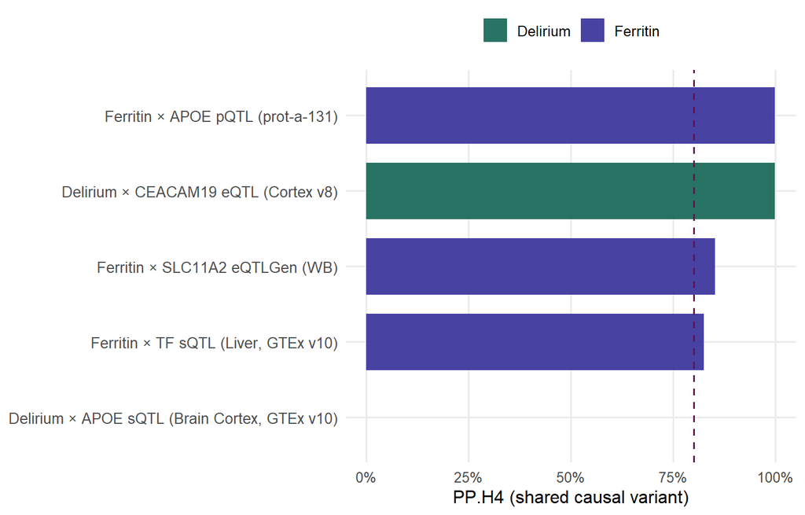

**Figure S10.** Colocalisation evidence across key tests (PP.H4). Posterior probability of a shared causal variant (PP.H4) across key GWAS–QTL/proxy comparisons. The dashed line marks the PP.H4 ≥ 0.80 threshold to denote strong shared-signal support.

**Locus deep dive: APOE**

**Why this matters.** APOE/TOMM40/CEACAM19 is a multi-signal LD block; coloc.abf can show H3 even when a shared subset exists, so SuSiE component-level checks are informative.

Table S16: SuSiE–coloc (Ferritin GWAS × APOE pQTL): top component pairs ranked by PP.H4.abf.

| nsnps | hit1 | hit2 | PP.H0.abf | PP.H1.abf | PP.H2.abf | PP.H3.abf | PP.H4.abf | idx1 | idx2 |
| --- | --- | --- | --- | --- | --- | --- | --- | --- | --- |
| 3576 | rs106433 | rs106433 | 0 | 0 | 0 | 0 | 1 | 1 | 1 |
| 3576 | rs1065853 | rs1065853 | 0 | 0 | 0 | 0 | 1 | 3 | 3 |
| 3576 | rs106433 | rs111243475 | 0 | 0 | 0 | 1 | 0 | 1 | 2 |
| 3576 | rs1065853 | rs111243475 | 0 | 0 | 0 | 1 | 0 | 3 | 2 |
| 3576 | rs1065853 | rs106433 | 0 | 0 | 0 | 1 | 0 | 3 | 1 |
| 3576 | rs106433 | rs1065853 | 0 | 0 | 0 | 1 | 0 | 1 | 3 |

**Table S16.** Top SuSiE component-pair matches for Ferritin GWAS × APOE pQTL, ranked by PP.H4.abf, reporting best-aligned SNP pairs and posterior breakdown.

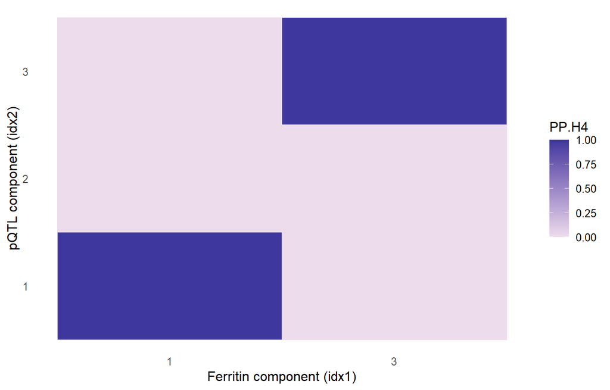

**Figure S11.** Component-pair heatmap. SuSiE–coloc component-pair matrix showing PP.H4 support for shared signals between Ferritin GWAS components and APOE pQTL components. Darker cells indicate stronger colocalisation.

Table S17: SuSiE summary for Delirium GWAS × APOE pQTL: credible sets, lead SNPs, and the best observed component overlap (PP_shared).

| comparison | delirium_CS | delirium_leads | pqtl_CS | pqtl_leads | max_PP_shared |
| --- | --- | --- | --- | --- | --- |
| Delirium GWAS × APOE pQTL (SuSiE) | NA |  | NA |  | 6.000e-04 |

**Table S17.** SuSiE summary for Delirium GWAS × APOE pQTL, listing credible sets, lead SNPs, and the maximum observed shared-signal probability (PP_shared).

**Locus deep dive: CEACAM19**

Table S18: Delirium × CEACAM19 (Cortex v8) coloc.abf summary table (as recorded in runlist).

| nsnps | PP.H0.abf | PP.H1.abf | PP.H2.abf | PP.H3.abf | PP.H4.abf |
| --- | --- | --- | --- | --- | --- |
| 5 | 0 | 0 | 0.0007387 | 0.0010049 | 0.9982564 |

**Table S18.** Coloc.abf posterior probabilities (H0–H4) for Delirium GWAS × CEACAM19 eQTL in cortex (v8), as recorded in the runlist.

Table S19: Top SNPs by PP.H4 for Delirium × CEACAM19 (Cortex v8).

| snp | PP.H4 |
| --- | --- |
| 19:44646342 | 0.7436349 |
| 19:44662645 | 0.2563651 |
| 19:44677956 | 0.0000000 |
| 19:44683693 | 0.0000000 |
| 19:44619993 | 0.0000000 |

**Table S19.** SNP-level ranking by PP.H4 for the Delirium × CEACAM19 cortex colocalisation window, highlighting variants driving the shared-signal posterior.

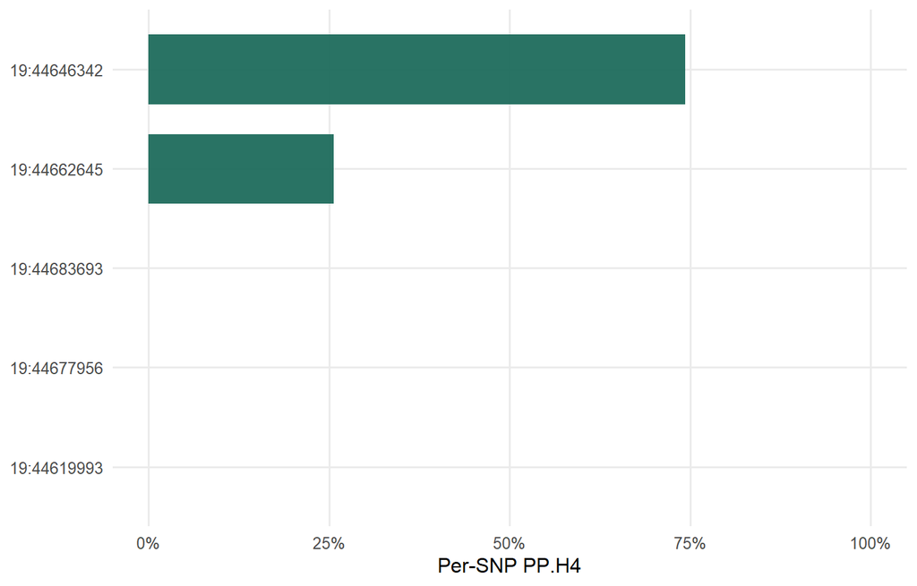

**Figure S12.** Per-SNP PP.H4 at the CEACAM19 locus. SNP-level PP.H4 contributions for Delirium × CEACAM19 cortex colocalisation, highlighting the variants that drive the shared-signal posterior in this region.

Table S20. Lead SNP details (aligned effects) for Delirium × CEACAM19 (Cortex v8).

| SNP | beta_gwas | se_gwas | maf_gwas | slope_eqtl | se_eqtl | maf_eqtl | PP.H4 |
| --- | --- | --- | --- | --- | --- | --- | --- |
| 19:44646342 | -0.116987 | 0.0236655 | 0.11856 | -0.585555 | 0.0773764 | 0.097561 | 0.7436349 |

**Table S20.** Lead-variant effect alignment for Delirium GWAS and CEACAM19 cortex eQTL (betas/SE/MAF) alongside PP.H4, supporting interpretation of the colocalised signal.